# Mediation Analysis

Victoria Brookes

2023-05-10

This tutorial is a summary of the example from, ‘Introduction to Mediation Analysis’, available at https://data.library.virginia.edu/introduction-to-mediation-analysis/, by Bommae Kim, Statistical Consulting Associate, University of Virginia Library.

#### Download data

```r
urlfile = "https://raw.githubusercontent.com/vikijbrookes/EITV/main/mediationData.csv"
medDF = read.csv(urlfile)

str(medDF)
```

```
## 'data.frame':    100 obs. of  3 variables:
##  $ X: int  6 7 7 8 4 4 9 5 8 4 ...
##  $ M: int  5 5 7 4 3 4 7 0 7 3 ...
##  $ Y: int  6 5 4 8 5 7 8 4 7 4 ...
```

```r
head(medDF)
```

```
##   X M Y
## 1 6 5 6
## 2 7 5 5
## 3 7 7 4
## 4 8 4 8
## 5 4 3 5
## 6 4 4 7
```

### Plot the data

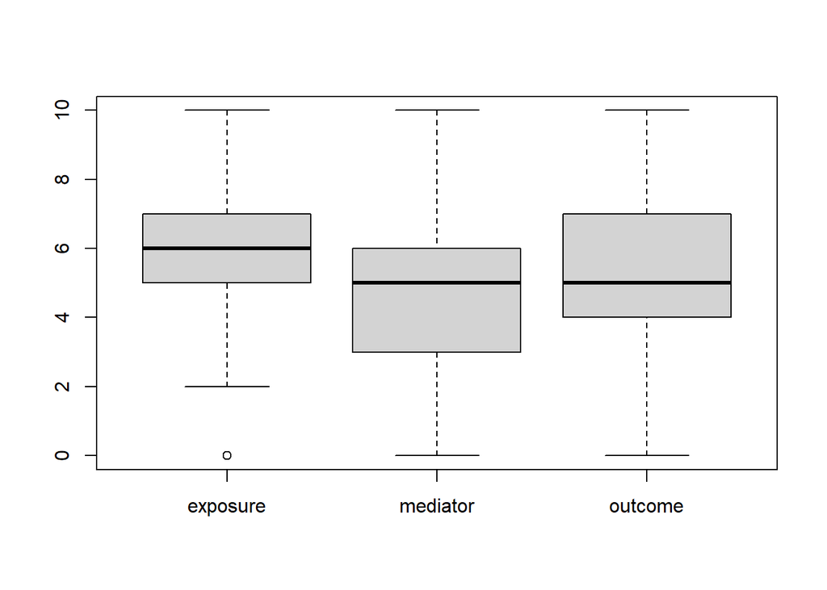

```r
boxplot(medDF$X, medDF$M, medDF$Y,  names = c('exposure', 'mediator', 'outcome'))
```

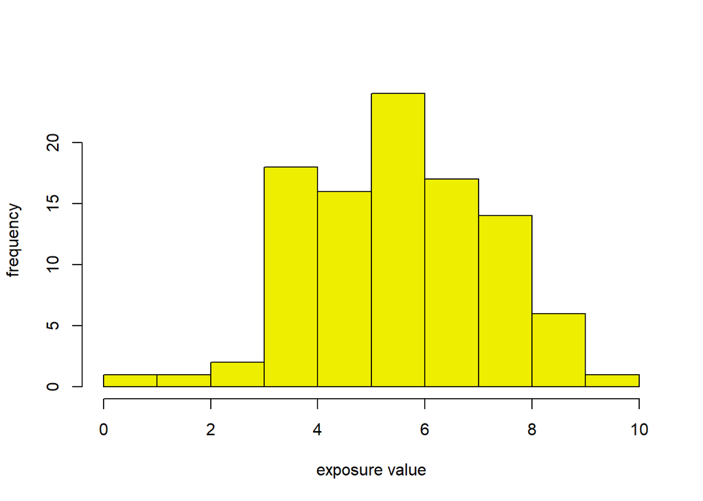

```r
hist(medDF$X, main = '', xlab = 'exposure value', ylab = 'frequency', breaks = 'fd', col = 'yellow2')
```

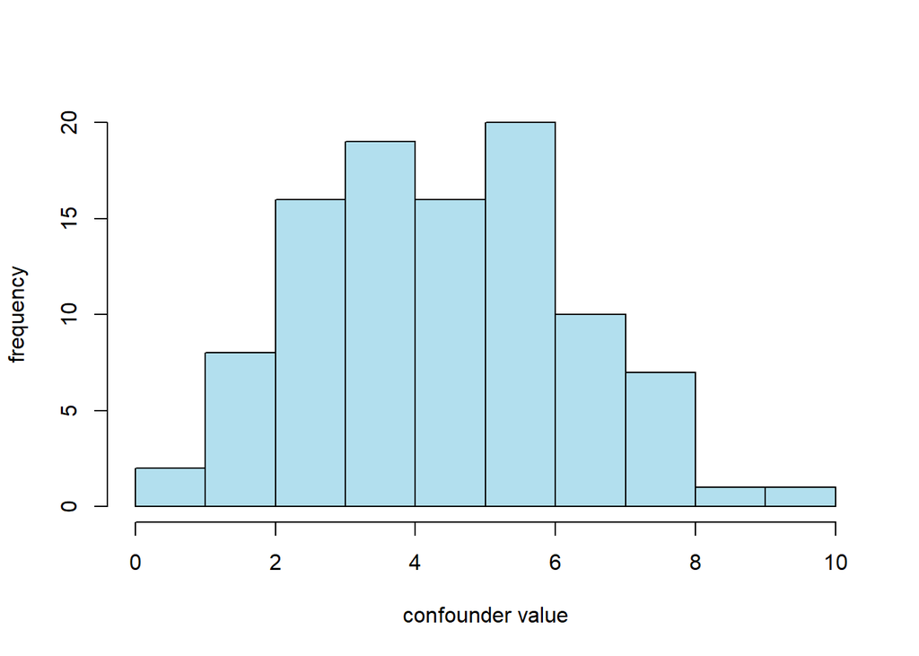

```r
hist(medDF$M, main = '', xlab = 'confounder value', ylab = 'frequency', breaks = 'fd', col = 'lightblue2')
```

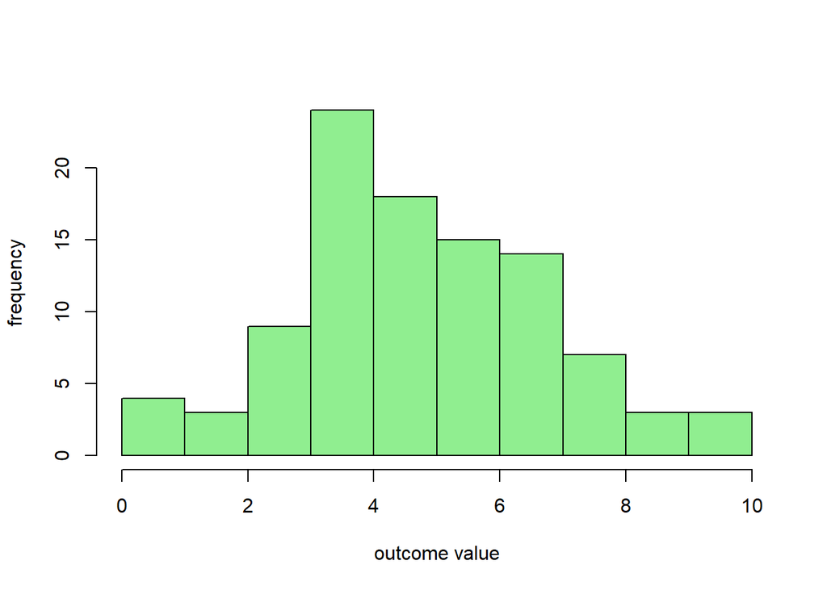

```r
hist(medDF$Y, main = '', xlab = 'outcome value', ylab = 'frequency', breaks = 'fd', col = 'lightgreen')
```

```r
summary(medDF$X)
```

```
##    Min. 1st Qu.  Median    Mean 3rd Qu.    Max.
##    0.00    5.00    6.00    5.99    7.00   10.00
```

```r
summary(medDF$M)
```

```
##    Min. 1st Qu.  Median    Mean 3rd Qu.    Max.
##    0.00    3.00    5.00    4.86    6.00   10.00
```

```r
summary(medDF$Y)
```

```
##    Min. 1st Qu.  Median    Mean 3rd Qu.    Max.
##    0.00    4.00    5.00    5.23    7.00   10.00
```

The following code steps through the method for mediation analysis suggested by Baron & Kenny (1986).

A mediation analysis is comprised of three sets of regression:

X → Y,

X → M, and

X + M → Y.

### Step 1

Is there a potentially causal association between X and Y? (Otherwise there is nothing to mediate!)

```r
model.0 <- lm(Y ~ X, medDF)
summary (model.0)
```

```
##
## Call:
## lm(formula = Y ~ X, data = medDF)
##
## Residuals:
##     Min      1Q  Median      3Q     Max
## -5.0262 -1.2340 -0.3282  1.5583  5.1622
##
## Coefficients:
##             Estimate Std. Error t value Pr(>|t|)
## (Intercept)   2.8572     0.6932   4.122 7.88e-05 ***
## X             0.3961     0.1112   3.564 0.000567 ***
## ---
## Signif. codes:  0 '***' 0.001 '**' 0.01 '*' 0.05 '.' 0.1 ' ' 1
##
## Residual standard error: 1.929 on 98 degrees of freedom
## Multiple R-squared:  0.1147, Adjusted R-squared:  0.1057
## F-statistic:  12.7 on 1 and 98 DF,  p-value: 0.0005671
```

### Step 2

Does X influence M? If X and M have no relationship, M is just a third variable that may or may not be associated with Y. Mediation analysis is only relevant for M if X affects M.

```r
model.M <- lm(M ~ X, medDF)
summary(model.M)
```

```
##
## Call:
## lm(formula = M ~ X, data = medDF)
##
## Residuals:
##     Min      1Q  Median      3Q     Max
## -4.3046 -0.8656  0.1344  1.1344  4.6954
##
## Coefficients:
##             Estimate Std. Error t value Pr(>|t|)
## (Intercept)  1.49952    0.58920   2.545   0.0125 *
## X            0.56102    0.09448   5.938 4.39e-08 ***
## ---
## Signif. codes:  0 '***' 0.001 '**' 0.01 '*' 0.05 '.' 0.1 ' ' 1
##
## Residual standard error: 1.639 on 98 degrees of freedom
## Multiple R-squared:  0.2646, Adjusted R-squared:  0.2571
## F-statistic: 35.26 on 1 and 98 DF,  p-value: 4.391e-08
```

### Step 3

Assess the direct effect of X on Y. If a mediation effect exists, the effect of X on Y will change when M is included in the regression, because some of the effect of X on Y is neing mediated via M.

```r
model.Y <- lm(Y ~ X + M, medDF)
summary(model.Y)
```

```
##
## Call:
## lm(formula = Y ~ X + M, data = medDF)
##
## Residuals:
##     Min      1Q  Median      3Q     Max
## -3.7631 -1.2393  0.0308  1.0832  4.0055
##
## Coefficients:
##             Estimate Std. Error t value Pr(>|t|)
## (Intercept)   1.9043     0.6055   3.145   0.0022 **
## X             0.0396     0.1096   0.361   0.7187
## M             0.6355     0.1005   6.321 7.92e-09 ***
## ---
## Signif. codes:  0 '***' 0.001 '**' 0.01 '*' 0.05 '.' 0.1 ' ' 1
##
## Residual standard error: 1.631 on 97 degrees of freedom
## Multiple R-squared:  0.373,  Adjusted R-squared:  0.3601
## F-statistic: 28.85 on 2 and 97 DF,  p-value: 1.471e-10
```

Is the mediation effect significant?

Use mediate() from the ‘mediation’ package.

mediate() takes two model objects as inputs (X → M and X + M → Y) and we need to specify which variable is the exposure (treatment) and which is the mediator (mediator).

For bootstrapping, set boot = TRUE and sims to at least 500.

For details of mediate(), refer to Tingley, Yamamoto, Hirose, Keele, & Imai (2014).

```r
library(mediation)
results <- mediate(model.M, model.Y, treat='X', mediator='M',
                   boot=TRUE, sims=500)
```

```
## Running nonparametric bootstrap
```

```r
summary(results)
```

```
##
## Causal Mediation Analysis
##
## Nonparametric Bootstrap Confidence Intervals with the Percentile Method
##
##                Estimate 95% CI Lower 95% CI Upper p-value
## ACME             0.3565       0.2135         0.52  <2e-16 ***
## ADE              0.0396      -0.1980         0.32     0.7
## Total Effect     0.3961       0.1426         0.65  <2e-16 ***
## Prop. Mediated   0.9000       0.4671         2.20  <2e-16 ***
## ---
## Signif. codes:  0 '***' 0.001 '**' 0.01 '*' 0.05 '.' 0.1 ' ' 1
##
## Sample Size Used: 100
##
##
## Simulations: 500
```

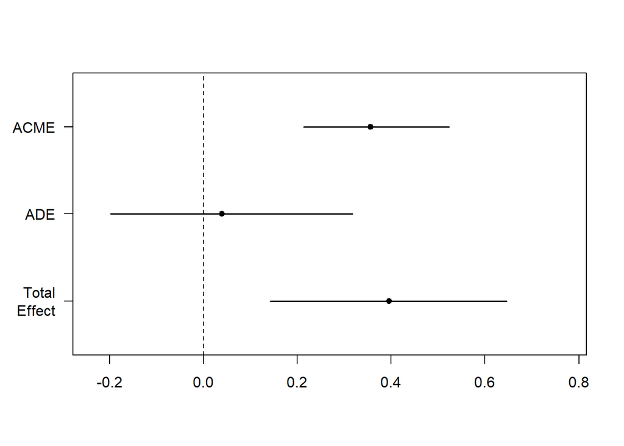

```r
plot(results)
```

The Total Effect in the summary (0.3961) is b1 in the first step: a total effect of X on Y (without M).

The direct effect (ADE, 0.0396) is b4 in the third step: a direct effect of X on Y after taking into account a mediation (indirect) effect of M.

Finally, examine the ACME (Average Causal Mediation Effects). This is the total effect minus the direct effect ( b1–b4, or 0.3961 - 0.0396 = 0.3565), which equals to a product of a coefficient of X in the second step and a coefficient of M in the last step ( b2×b3, or 0.56102 * 0.6355 = 0.3565).

Prop.mediated describes the proportion of the effect of X on Y that goes through the mediator, M.

‘The goal of mediation analysis is to obtain this indirect effect and see if it’s statistically significant.’

#### References

1. Baron, R. M., & Kenny, D. A. (1986). The moderator–mediator variable distinction in social psychological research: Conceptual, strategic, and statistical considerations. Journal of Personality and Social Psychology, 5, 1173-1182.
2. Shrout, P. E., & Bolger, N. (2002). Mediation in experimental and nonexperimental studies: new procedures and recommendations. Psychological Methods, 7, 422-445.
3. Tingley, D., Yamamoto, T., Hirose, K., Keele, L., & Imai, K. (2014). Mediation: R package for causal mediation analysis.
4. Lee H, Cashin AG, Lamb SE, et al. A Guideline for Reporting Mediation Analyses of Randomized Trials and Observational Studies: The AGReMA Statement. JAMA. 2021;326(11):1045–1056. doi:10.1001/jama.2021.14075